# RNA-Seq Expression and Functional Pathway Analysis

## Package Setup

```r
install.packages("BiocManager")

options(repos = BiocManager::repositories()
        )
BiocManager::install(c("DESeq2", "clusterProfiler", "org.Hs.eg.db", "enrichplot"), ask = FALSE, update = FALSE)
install.packages(c("DESeq2", "clusterProfiler", "org.Hs.eg.db", "enrichplot", "ggplot2", "dplyr", "knitr"))
```

```r
library(DESeq2)
library(clusterProfiler)
library(org.Hs.eg.db)
library(enrichplot)
library(ggplot2)
library(dplyr)
library(knitr)
```

## Load Assignment 2 Outputs

```r
dds <- readRDS("dds_GSE184717.rds")
results_deseq <- readRDS("results_deseq_GSE184717.rds")
```

## 1. Hierarchical Clustering

### 1.1 Extract Normalized Counts

```r
normalized_counts <- counts(dds, normalized = TRUE)

dim(normalized_counts)
```

```
## [1] 22507    42
```

### 1.2 Log2 Normalization

```r
log_norm_counts <- log2(normalized_counts + 1)

dim(log_norm_counts)
```

```
## [1] 22507    42
```

### 1.3 Filter to most variable genes

```r
gene_variance <- apply(log_norm_counts, 1, var)

top_var_genes <- names(sort(gene_variance, decreasing = TRUE))[1:100]

top_var_matrix <- log_norm_counts[top_var_genes, ]

dim(top_var_matrix)
```

```
## [1] 100  42
```

### 1.4 Hierarchical Clustering for Genes

#### 1.4.1 Distance between genes

```r
gene_dist <- dist(top_var_matrix)
```

#### 1.4.2 Hierarchical Clustering

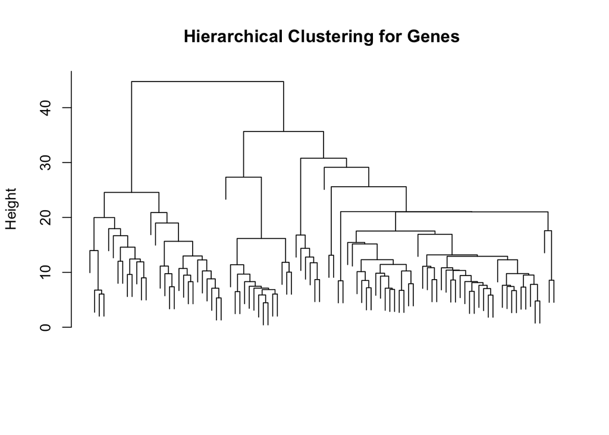

```r
gene_clusters <- hclust(gene_dist, method = "average")

plot(gene_clusters,
     main = "Hierarchical Clustering for Genes",
     labels = FALSE,
     xlab = "",
     sub = ""
)
```

Hierarchical clustering of the 100 most variable genes identified two major clusters, with one cluster (right) dividing into several smaller subclusters (around heights 20-30). The formation of distinct subclusters suggests that some genes have similar expression patterns across samples, which may indicate co-expression or shared involvement in the same biological pathways (Serin et al., 2016). The second major cluster (left) showed fewer distinct subclusters in comparison, indicating less variation in gene expression patterns (Tucker et al., 2020). To determine the biological significance of the genes driving these clusters, Gene Ontology and KEGG enrichment analyses are addressed in Section 3.

### 1.5 Hierarchical Clustering for Samples

#### 1.5.1 Distance between samples

```r
# Transpose dataset
sample_dist <- dist(t(top_var_matrix))
```

#### 1.5.2 Hierarchical Clustering

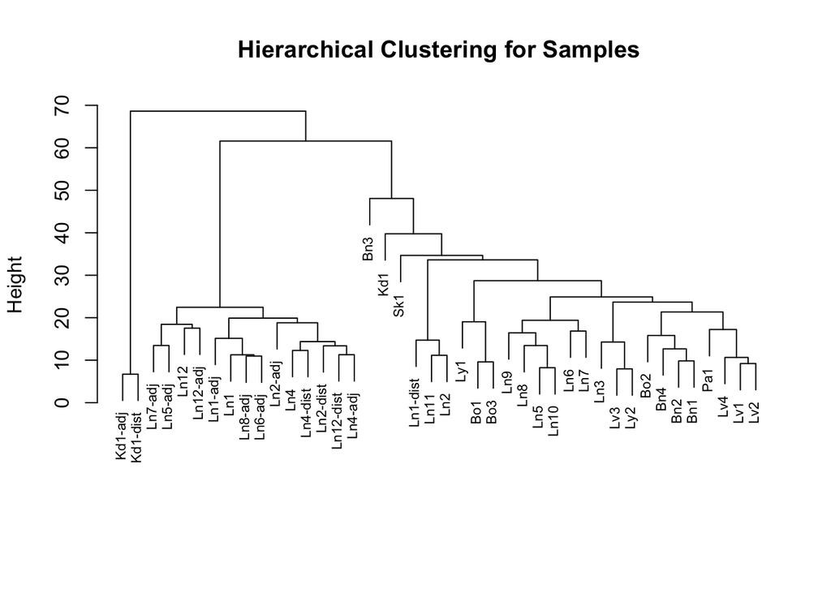

```r
sample_clusters <- hclust(sample_dist, method = "average")

plot(sample_clusters,
     main = "Hierarchical Clustering for Samples",
     xlab = "",
     sub = "",
     cex = 0.7
)
```

Hierarchical clustering of samples based on the 100 most variable genes showed a clear separation between tumor and normal samples, regardless of the organ they came from. Nearly all the tumor samples clustered together, while the adjacent/distant normal samples formed a separate branch. Overall, the samples grouped more by tumor status than the organ of origin, with only a few exceptions.

## 2. Gene List Selection (Fold-Change and P-value Cutoff)

### 2.1 Data Preparation

```r
results_df <- as.data.frame(results_deseq)

results_df$gene <- rownames(results_df)

head(results_df)
```

```
##                baseMean log2FoldChange     lfcSE     stat       pvalue
## DDX11L1       14.828143      2.9583222 0.5912849 5.003210 5.638355e-07
## WASH7P       152.845442      0.6917656 0.1699702 4.069923 4.702859e-05
## OR4F5          1.988717      3.8998720 1.0501191 3.713743 2.042164e-04
## LOC729737     85.080429      0.6538471 0.3171114 2.061885 3.921871e-02
## LOC100133331  62.646977      0.8596198 0.2543474 3.379708 7.256281e-04
## LOC100288069  30.070527      1.1472350 0.2477877 4.629911 3.658225e-06
##                      padj         gene
## DDX11L1      3.063145e-06      DDX11L1
## WASH7P       1.425744e-04       WASH7P
## OR4F5        5.253452e-04        OR4F5
## LOC729737    5.847602e-02    LOC729737
## LOC100133331 1.630074e-03 LOC100133331
## LOC100288069 1.523324e-05 LOC100288069
```

### 2.2 P-value Cutoff

```r
adj_pval <- results_df[!is.na(results_df$padj) & results_df$padj < 0.05, ]

dim(adj_pval)
```

```
## [1] 14829     7
```

### 2.3 Fold-change Filter

```r
fc_genes <- results_df[!is.na(results_df$log2FoldChange) & abs(results_df$log2FoldChange) >1, ]

dim(fc_genes)
```

```
## [1] 10339     7
```

```r
head(fc_genes)
```

```
##               baseMean log2FoldChange     lfcSE     stat       pvalue
## DDX11L1      14.828143       2.958322 0.5912849 5.003210 5.638355e-07
## OR4F5         1.988717       3.899872 1.0501191 3.713743 2.042164e-04
## LOC100288069 30.070527       1.147235 0.2477877 4.629911 3.658225e-06
## FAM41C       10.993353       3.390440 0.6231248 5.441029 5.297379e-08
## SAMD11       46.698037       1.084581 0.4213278 2.574197 1.004729e-02
## PLEKHN1      27.520576       1.900196 0.4613480 4.118792 3.808643e-05
##                      padj         gene
## DDX11L1      3.063145e-06      DDX11L1
## OR4F5        5.253452e-04        OR4F5
## LOC100288069 1.523324e-05 LOC100288069
## FAM41C       4.038386e-07       FAM41C
## SAMD11       1.717303e-02       SAMD11
## PLEKHN1      1.185631e-04      PLEKHN1
```

## 3. GO and KEGG Gene Annotations

### 3.1 GO Enrichment

#### 3.1.1 GO: Adjusted p-value list

```r
go_adj_pval <- enrichGO(gene = adj_pval$gene,
                        OrgDb = org.Hs.eg.db,
                        keyType = "SYMBOL",
                        ont = "BP",
                        pAdjustMethod = "BH",
                        pvalueCutoff = 0.05)

head(go_adj_pval)
```

```
##                    ID
## GO:0050907 GO:0050907
## GO:0050911 GO:0050911
## GO:0007608 GO:0007608
## GO:0045109 GO:0045109
## GO:0043588 GO:0043588
## GO:0007601 GO:0007601
##                                                                       Description
## GO:0050907          detection of chemical stimulus involved in sensory perception
## GO:0050911 detection of chemical stimulus involved in sensory perception of smell
## GO:0007608                                            sensory perception of smell
## GO:0045109                                     intermediate filament organization
## GO:0043588                                                       skin development
## GO:0007601                                                      visual perception
##            GeneRatio   BgRatio       pvalue     p.adjust       qvalue
## GO:0050907 386/10763 477/18903 2.785097e-29 1.805300e-25 1.593076e-25
## GO:0050911 350/10763 431/18903 3.352914e-27 1.086680e-23 9.589335e-24
## GO:0007608 364/10763 457/18903 3.425995e-25 7.402433e-22 6.532230e-22
## GO:0045109  61/10763  69/18903 1.353750e-08 2.193752e-05 1.935863e-05
## GO:0043588 218/10763 302/18903 2.444018e-08 3.168425e-05 2.795956e-05
## GO:0007601 162/10763 220/18903 1.797078e-07 1.756899e-04 1.550365e-04
##                                                                                                                                                                                                                                                                                                          …
## GO:0050907 OR4F5/TAS1R3/CA6/TAS1R2/OR10T2/OR10K2/OR10K1/OR10R2/OR6Y1/OR…
## GO:0050911                                                                                                                                                                                                                                              OR4F5/OR10T2/OR10K2/OR10K1/OR10R2/OR6Y1/OR6P1/OR1…
## GO:0007608                                                                                                                                                              OR4F5/GJB4/OR10T2/OR10K2/OR10K1/OR10R2/OR6Y1/OR6P1/OR10X1/OR…
## GO:0045109                                                                                                                                                                                                                                                                                               …
## GO:0043588                                                                                                                                                                                                                                                                                               …
## GO:0007601                                                                                                                                                                                                                                                                                               …
##            Count
## GO:0050907   386
## GO:0050911   350
## GO:0007608   364
## GO:0045109    61
## GO:0043588   218
## GO:0007601   162
```

#### 3.1.2 GO: Fold change list

```r
go_fc_genes <- enrichGO(gene = fc_genes$gene,
                        OrgDb = org.Hs.eg.db,
                        keyType = "SYMBOL",
                        ont = "BP",
                        pAdjustMethod = "BH",
                        pvalueCutoff = 0.05)

head(go_fc_genes)
```

```
##                    ID
## GO:0050907 GO:0050907
## GO:0050911 GO:0050911
## GO:0007608 GO:0007608
## GO:0031424 GO:0031424
## GO:0008544 GO:0008544
## GO:0007218 GO:0007218
##                                                                       Description
## GO:0050907          detection of chemical stimulus involved in sensory perception
## GO:0050911 detection of chemical stimulus involved in sensory perception of smell
## GO:0007608                                            sensory perception of smell
## GO:0031424                                                         keratinization
## GO:0008544                                                  epidermis development
## GO:0007218                                         neuropeptide signaling pathway
##            GeneRatio   BgRatio       pvalue     p.adjust       qvalue
## GO:0050907  393/7043 477/18903 2.005162e-93 1.283705e-89 1.002159e-89
## GO:0050911  360/7043 431/18903 6.087387e-89 1.948573e-85 1.521206e-85
## GO:0007608  374/7043 457/18903 3.403064e-87 7.262140e-84 5.669386e-84
## GO:0031424   70/7043  84/18903 4.301704e-18 6.884877e-15 5.374866e-15
## GO:0008544  209/7043 362/18903 1.233854e-15 1.579826e-12 1.233334e-12
## GO:0007218   82/7043 110/18903 1.679939e-15 1.792495e-12 1.399360e-12
##                                                                                                                                                                                                                                                                                                          …
## GO:0050907 OR4F5/TAS1R3/CA6/TAS1R2/OR10T2/OR10K2/OR10K1/OR10R2/OR6Y1/OR…
## GO:0050911                                                                                                                                                                                                                        OR4F5/OR10T2/OR10K2/OR10K1/OR10R2/OR6Y1/OR6P1/OR10X1/OR10Z1/…
## GO:0007608                                                                                                                                        OR4F5/GJB4/OR10T2/OR10K2/OR10K1/OR10R2/OR6Y1/OR6P1/OR10X1/OR…
## GO:0031424                                                                                                                                                                                                                                                                                               …
## GO:0008544                                                                                                                                                                                                                                                                                               …
## GO:0007218                                                                                                                                                                                                                                                                                               …
##            Count
## GO:0050907   393
## GO:0050911   360
## GO:0007608   374
## GO:0031424    70
## GO:0008544   209
## GO:0007218    82
```

GO enrichment analysis for both gene lists identified mostly olfactory receptor (OR) and sensory perception terms, likely due to large number of olfactory receptor genes in the human genome instead of biological processes associated with breast cancer (Yoshihito Niimura, 2012). Looking past the top results, the Fold-change GO enrichment identified terms related to keratinization, epidermis development, and neuropeptide signaling pathway. This likely reflects the variety of tissues sampled (including a skin sample), as opposed to tumor-specific expression patterns.

### 3.2 KEGG Enrichment

#### 3.2.1 Convert gene symbols to Entrez IDS

```r
# Ajusted p-value gene list
adj_pval_entrez <- bitr(adj_pval$gene,
                        fromType = "SYMBOL",
                        toType = "ENTREZID",
                        OrgDb = org.Hs.eg.db)
dim(adj_pval_entrez)
```

```
## [1] 12715     2
```

```r
# Fold-change gene list
fc_genes_entrez <- bitr(fc_genes$gene,
                        fromType = "SYMBOL",
                        toType = "ENTREZID",
                        OrgDb = org.Hs.eg.db)
dim(fc_genes_entrez)
```

```
## [1] 8797    2
```

#### 3.2.2 KEGG: Adjusted p-value list

```r
kegg_adj_pval <- enrichKEGG(gene = adj_pval_entrez$ENTREZID,
                            organism = "hsa",
                            pAdjustMethod = "BH",
                            pvalueCutoff = 0.05)
```

```
## Reading KEGG annotation online: "https://rest.kegg.jp/link/hsa/pathway"...
```

```
## Reading KEGG annotation online: "https://rest.kegg.jp/list/pathway/hsa"...
```

```r
head(kegg_adj_pval)
```

```
##                ID                             Description GeneRatio  BgRatio
## hsa04740 hsa04740                  Olfactory transduction  370/5379 449/9451
## hsa04080 hsa04080 Neuroactive ligand-receptor interaction  283/5379 371/9451
## hsa04742 hsa04742                      Taste transduction   73/5379  86/9451
## hsa04082 hsa04082            Neuroactive ligand signaling  150/5379 199/9451
## hsa04382 hsa04382            Cornified envelope formation  160/5379 217/9451
## hsa04519 hsa04519                      Cadherin signaling  278/5379 404/9451
##                pvalue     p.adjust       qvalue
## hsa04740 6.418938e-32 2.259466e-29 1.601356e-29
## hsa04080 1.680971e-15 2.958509e-13 2.096790e-13
## hsa04742 2.368050e-08 2.778512e-06 1.969220e-06
## hsa04082 3.370156e-08 2.965737e-06 2.101913e-06
## hsa04382 1.536104e-07 1.081417e-05 7.664349e-06
## hsa04519 3.552198e-07 2.083956e-05 1.476967e-05
##                                                                                                                                                                                                                                                                                                          …
## hsa04740 79501/2782/163688/128360/391107/391109/343406/391112/128366/…
## hsa04080                                                                                                                                                                                                                                                                                                 …
## hsa04742                                                                                                                                                                                                                                                                                                 …
## hsa04082                                                                                                                                                                                                                                                                                                 …
## hsa04382                                                                                                                                                                                                                                                                                                 …
## hsa04519                                                                                                                                                                                                                                                                                                 …
##          Count
## hsa04740   370
## hsa04080   283
## hsa04742    73
## hsa04082   150
## hsa04382   160
## hsa04519   278
```

#### 3.2.3 KEGG: Fold-change list

```r
kegg_fc_genes <- enrichKEGG(gene = fc_genes_entrez$ENTREZID,
                            organism = "hsa",
                            pAdjustMethod = "BH",
                            pvalueCutoff = 0.05)

head(kegg_fc_genes)
```

```
##                ID                             Description GeneRatio  BgRatio
## hsa04740 hsa04740                  Olfactory transduction  370/3570 449/9451
## hsa04080 hsa04080 Neuroactive ligand-receptor interaction  272/3570 371/9451
## hsa04060 hsa04060  Cytokine-cytokine receptor interaction  198/3570 298/9451
## hsa04082 hsa04082            Neuroactive ligand signaling  136/3570 199/9451
## hsa04382 hsa04382            Cornified envelope formation  143/3570 217/9451
## hsa04081 hsa04081                       Hormone signaling  139/3570 219/9451
##                pvalue     p.adjust       qvalue
## hsa04740 4.025035e-88 1.416812e-85 1.080404e-85
## hsa04080 1.176329e-45 2.070339e-43 1.578757e-43
## hsa04060 2.325744e-24 2.728873e-22 2.080929e-22
## hsa04082 1.060276e-18 9.330431e-17 7.115012e-17
## hsa04382 2.053170e-17 1.445431e-15 1.102228e-15
## hsa04081 6.190351e-15 3.631672e-13 2.769367e-13
##                                                                                                                                                                                                                                                                                                          …
## hsa04740 79501/163688/128360/391107/391109/343406/391112/128366/12836…
## hsa04080                                                                                                                                                                                                                                                                                                 …
## hsa04060                                                                                                                                                                                                                                                                                                 …
## hsa04082                                                                                                                                                                                                                                                                                                 …
## hsa04382                                                                                                                                                                                                                                                                                                 …
## hsa04081                                                                                                                                                                                                                                                                                                 …
##          Count
## hsa04740   370
## hsa04080   272
## hsa04060   198
## hsa04082   136
## hsa04382   143
## hsa04081   139
```

KEGG enrichment showed a similar pattern to the GO analysis, mostly dominated by olfactory transduction and neuroactive ligand-receptor interaction as the top pathways in both gene lists. However, KEGG also identified pathways more relevant to cancer biology, including Cadherin Signaling (Yu et al., 2019) and Cytokine-Cytokine Receptor Interaction (Qu et al., 2024).

### 3.3 Which annotation is more reliable?

The most significant GO and KEGG terms were related to olfactory receptor genes and neuroactive ligand-receptor interactions. As previously stated, these results are likely due to the large size of the OR gene family rather than actual breast cancer biology (Yoshihito Niimura, 2012). Furthermore, these results are likely amplified by the dataset’s single-patient design and pseudoreplicates.

Outside of these top hits, both databases identified terms related to skin development and keratinization, most likely reflecting the tissue diversity of the biopsy sites. Unlike GO, KEGG additionally identified pathways with clearer links to cancer biology (e.g., cadherin signaling, cytokine-cytokine receptor interaction), suggesting that KEGG provided more biologically meaningful results for the dataset and is more reliable than GO enrichment in this case.

As discussed in the course lecture notes, an important limitation to consider is that KEGG enrichment analysis maps genes to predefined biological pathways, which may not reflect how those genes actually behave in this specific context. Therefore, these findings could be followed up with GSEA, which considers the full ranked gene list instead of only significant genes.

## 4. GSEA

### 4.1 Build ranked gene list

```r
# remove genes with missing log2FoldChange
gsea_input <-results_df[!is.na(results_df$log2FoldChange), ]

# remove duplicate gene symbols
gsea_input <- gsea_input[order(-abs(gsea_input$log2FoldChange)), ]
gsea_input <- gsea_input[!duplicated(gsea_input$gene), ]

# preserve gene ranking and sort in descending order
gene_list <- gsea_input$log2FoldChange
names(gene_list) <- gsea_input$gene

gene_list <- sort(gene_list, decreasing = TRUE)

length(gene_list)
```

```
## [1] 22507
```

```r
head(gene_list)
```

```
##     PSG7    FSTL5    KRT71    CDH18    LCE1B    ABCG8
## 7.287645 7.148262 7.047814 6.968648 6.947657 6.924967
```

```r
tail(gene_list)
```

```
##      GGT1      IL1B      CSF3      GPX3     CCL20   SCGB1A1
## -3.985066 -4.205876 -4.308472 -4.314473 -4.484662 -4.791508
```

### 4.2 Run GSEA with GO

```r
gsea_go <- gseGO(geneList = gene_list,
                 OrgDb = org.Hs.eg.db,
                 keyType = "SYMBOL",
                 ont = "BP",
                 pAdjustMethod = "BH",
                 pvalueCutoff = 0.05)
```

```
## preparing geneSet collections...
```

```
## GSEA analysis...
```

```
## leading edge analysis...
```

```
## done...
```

```r
head(gsea_go)
```

```
##                    ID
## GO:0002478 GO:0002478
## GO:0002495 GO:0002495
## GO:0019886 GO:0019886
## GO:0002504 GO:0002504
## GO:0050911 GO:0050911
## GO:0007608 GO:0007608
##                                                                                          Description
## GO:0002478                          antigen processing and presentation of exogenous peptide antigen
## GO:0002495                   antigen processing and presentation of peptide antigen via MHC class II
## GO:0019886         antigen processing and presentation of exogenous peptide antigen via MHC class II
## GO:0002504 antigen processing and presentation of peptide or polysaccharide antigen via MHC class II
## GO:0050911                    detection of chemical stimulus involved in sensory perception of smell
## GO:0007608                                                               sensory perception of smell
##            setSize enrichmentScore       NES pvalue  p.adjust       qvalue rank
## GO:0002478      36      -0.8314508 -3.866473  1e-10 5.111e-08 4.468421e-08 1960
## GO:0002495      28      -0.8457295 -3.826244  1e-10 5.111e-08 4.468421e-08 1979
## GO:0019886      26      -0.8617362 -3.710234  1e-10 5.111e-08 4.468421e-08 1812
## GO:0002504      30      -0.8309222 -3.647873  1e-10 5.111e-08 4.468421e-08 1979
## GO:0050911     367       0.7792739  1.976456  1e-10 5.111e-08 4.468421e-08 4450
## GO:0007608     391       0.7722602  1.959796  1e-10 5.111e-08 4.468421e-08 4450
##                              leading_edge
## GO:0002478  tags=72%, list=9%, signal=66%
## GO:0002495  tags=75%, list=9%, signal=68%
## GO:0019886  tags=77%, list=8%, signal=71%
## GO:0002504  tags=73%, list=9%, signal=67%
## GO:0050911 tags=91%, list=20%, signal=74%
## GO:0007608 tags=87%, list=20%, signal=71%
##                                                                                                                                                                                                                                                                                                          …
## GO:0002478                                                                                                                                                                                                                                                                                               …
## GO:0002495                                                                                                                                                                                                                                                                                               …
## GO:0019886                                                                                                                                                                                                                                                                                               …
## GO:0002504                                                                                                                                                                                                                                                                                               …
## GO:0050911                                                 OR10H5/OR7A17/OR10J1/OR6Y1/OR10H2/OR10R2/OR1G1/OR7C2/OR10K2/…
## GO:0007608 OR10H5/OR7A17/OR10J1/OR6Y1/OR10H2/OR10R2/OR1G1/OR7C2/OR10K2/…
```

### 4.3 Plot of Top GSEA-GO Result

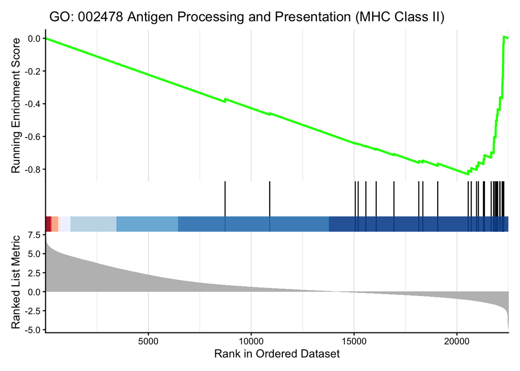

```r
gseaplot2(gsea_go, geneSetID = "GO:0002478", title = " GO: 002478 Antigen Processing and Presentation (MHC Class II)")
```

This finding is consistent with a well-known immune evasion mechanism in cancer, where tumors reduce antigen presentation to avoid detection by the immune system (Dhatchinamoorthy et al., 2021).

```r
# Change all genes to Entrez IDs
gsea_entrez <- bitr(gsea_input$gene,
                    fromType = "SYMBOL",
                    toType = "ENTREZID",
                    OrgDb = org.Hs.eg.db)
```

```r
# keep genes that successfully mapped
gsea_mapped <-gsea_input[gsea_input$gene %in% gsea_entrez$SYMBOL, ]

# attach entrez IDs to matching gene symbol
gsea_mapped$ENTREZID <- gsea_entrez$ENTREZID[match(gsea_mapped$gene, gsea_entrez$SYMBOL)]

# Remove duplicate Entrez IDs
gsea_mapped <- gsea_mapped[order(-abs(gsea_mapped$log2FoldChange)), ]
gsea_mapped <- gsea_mapped[!duplicated(gsea_mapped$ENTREZID), ]

# preserve gene ranking and sort in descending order
gene_list_entrez <- gsea_mapped$log2FoldChange
names(gene_list_entrez) <- gsea_mapped$ENTREZID

gene_list_entrez <- sort(gene_list_entrez, decreasing = TRUE)

length(gene_list_entrez)
```

```
## [1] 19314
```

```r
head(gene_list_entrez)
```

```
##     5676    56884   112802     1016   353132    64241
## 7.287645 7.148262 7.047814 6.968648 6.947657 6.924967
```

### 4.4.2 GSEA with KEGG

```r
gsea_kegg <- gseKEGG(geneList = gene_list_entrez,
                      organism = "hsa",
                      pAdjustMethod = "BH",
                      pvalueCutoff = 0.05)
```

```
## preparing geneSet collections...
```

```
## GSEA analysis...
```

```
## leading edge analysis...
```

```
## done...
```

```r
head(gsea_kegg)
```

```
##                ID                             Description setSize
## hsa05144 hsa05144                                 Malaria      48
## hsa05330 hsa05330                     Allograft rejection      36
## hsa04740 hsa04740                  Olfactory transduction     400
## hsa04080 hsa04080 Neuroactive ligand-receptor interaction     364
## hsa04082 hsa04082            Neuroactive ligand signaling     199
## hsa04382 hsa04382            Cornified envelope formation     210
##          enrichmentScore       NES       pvalue     p.adjust       qvalue rank
## hsa05144      -0.6838303 -3.096315 1.000000e-10 6.038889e-09 5.163218e-09 2299
## hsa05330      -0.7235192 -2.942075 1.478912e-10 6.038889e-09 5.163218e-09 1640
## hsa04740       0.7751953  1.995275 1.000000e-10 6.038889e-09 5.163218e-09 3703
## hsa04080       0.6067328  1.559570 1.000000e-10 6.038889e-09 5.163218e-09 4389
## hsa04082       0.6007264  1.534387 1.000000e-10 6.038889e-09 5.163218e-09 4996
## hsa04382       0.5875337  1.499745 1.381359e-10 6.038889e-09 5.163218e-09 3332
##                            leading_edge
## hsa05144 tags=65%, list=12%, signal=57%
## hsa05330  tags=64%, list=8%, signal=59%
## hsa04740 tags=85%, list=19%, signal=70%
## hsa04080 tags=54%, list=23%, signal=43%
## hsa04082 tags=55%, list=26%, signal=41%
## hsa04382 tags=42%, list=17%, signal=35%
##                                                                                                                                                                                                                                                                                                          …
## hsa05144                                                                                                                                                                                                                                                                                                 …
## hsa05330                                                                                                                                                                                                                                                                                                 …
## hsa04740 284433/26333/26476/391112/26538/343406/8390/26658/391107/391…
## hsa04080                                                                                                                                                                                                                                                                                                 …
## hsa04082                                                                                                                                                                                                                                                                                                 …
## hsa04382                                                                                                                                                                                                                                                                                                 …
```

### 4.4.3 Plot of Top GSEA-KEGG Result

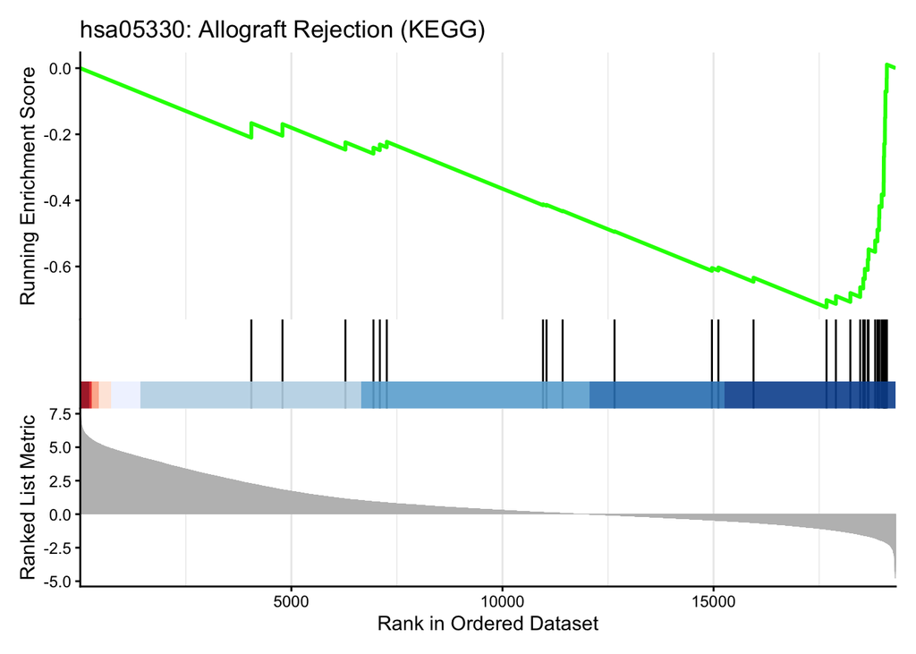

```r
gseaplot2(gsea_kegg, geneSetID = "hsa05330", title = "hsa05330: Allograft Rejection (KEGG)")
```

The plot also visually confirms this pattern.

## 5. Summary and Conclusions

This analysis extended Assignment 2’s differential expression results (GSE184717) through hierarchical clustering, functional annotation via GO and KEGG, and gene set enrichment analysis.

Hierarchical clustering of the 100 most variable genes separated the samples by tumor status instead of organ origin, indicating that this was the primary source of variation. Gene clustering identified two major clusters, with one containing several, smaller subclusters that may represent groups of co-expressed genes.

GO and KEGG annotation of two independently selected gene lists (p-value and fold-change cutoffs) consistently identified olfactory receptor and sensory perception terms as the most significant results. Skin- and keratin-related terms were also identified, highlighting the tissue diversity of the study design. KEGG’s enrichment analysis was somewhat more interpretable than GO’s, identifying potentially cancer-relevant pathways like cadherin signaling and cytokine-cytokine interactions.

GSEA provided the most biologically meaningful result. Both GSEA-GO and GSEA-KEGG identified reduced expression of MHC class II antigen presentation and related immune pathways in tumor samples. These findings are consistent with known mechanisms of immune evasion in cancer.

Overall, the assignment highlights the strengths and limitations of enrichment analyses. Because the dataset only includes one patient, these results should be interpreted as patient-specific rather than generalizable breast cancer biomarkers. However, the repeated immune-evasion signal identified by different databases supports further investigation in larger cohorts.

## References:

Dhatchinamoorthy, K., Colbert, J. D., & Rock, K. L. (2021). Cancer Immune Evasion Through Loss of MHC Class I Antigen Presentation. Frontiers in Immunology, 12. https://doi.org/10.3389/fimmu.2021.636568

Huang, X., Qiao, Y., Brady, S. W., Factor, R. E., Downs-Kelly, E., Farrell, A., McQuerry, J. A., Shrestha, G., Jenkins, D., Johnson, W. E., Cohen, A. L., Bild, A. H., & Marth, G. T. (2021). Novel temporal and spatial patterns of metastatic colonization from breast cancer rapid-autopsy tumor biopsies. Genome Medicine, 13(1), 170. https://doi.org/10.1186/s13073-021-00989-6

Qu, R., Zhao, Y., & Zhang, Y. (2024). The mechanism of cytokine regulation of cancer occurrence and development in the tumor microenvironment and its application in cancer treatment: a narrative review. Translational Cancer Research, 13(10), 5649–5663. https://doi.org/10.21037/tcr-24-679

Tucker, N. R., Chaffin, M., Fleming, S. J., Hall, A. W., Parsons, V. A., Bedi, K. C., Akkad, A.-D., Herndon, C. N., Arduini, A., Papangeli, I., Roselli, C., Aguet, F., Choi, S. H., Ardlie, K. G., Babadi, M., Margulies, K. B., Stegmann, C. M., & Ellinor, P. T. (2020). Transcriptional and Cellular Diversity of the Human Heart. Circulation, 142(5), 466–482. https://doi.org/10.1161/circulationaha.119.045401

Serin, E. A. R., Nijveen, H., Hilhorst, H. W. M., & Ligterink, W. (2016). Learning from Co-expression Networks: Possibilities and Challenges. Frontiers in Plant Science, 7. https://doi.org/10.3389/fpls.2016.00444

Significance of Positive and Negative Correlation of Genes in GSEA Analysis. (2026). Cd-Genomics.com. https://bioinfo.cd-genomics.com/resource-positive-and-negative-correlation-of-genes-in-gsea-analysis.html

Yoshihito Niimura. (2012). Olfactory Receptor Multigene Family in Vertebrates: From the Viewpoint of Evolutionary Genomics. Current Genomics, 13(2), 103–114. https://doi.org/10.2174/138920212799860706

Yu, W., Yang, L., Li, T., & Zhang, Y. (2019). Cadherin Signaling in Cancer: Its Functions and Role as a Therapeutic Target. Frontiers in Oncology, 9. https://doi.org/10.3389/fonc.2019.00989